# Monte Carlo - Part 2

## Recap

We are interested in *computing integrals* or *expectations* of a random variable \(X\), with density \(f(x)\), on \(\mathbb{R}\). Let \(h(x)\) denote a function whose expectation we would like to compute, i.e. \[ \mathbb{E}_f[h(X)] := \int_\mathbb{R} h(x) f(x) \;\textrm{d}x . \]

For \(x_1, \dots, x_n\) drawn i.i.d. from \(X\), the *Monte-Carlo estimator* is \[ \bar{h}_n := \frac{1}{n} \sum_{j=1}^n h(x_j) . \]

## This Lecture

1. Does the Monte-Carlo Estimator converge?
2. How can we measure the error?

Where to find these slides: github.com/jcockayne/math3092_2021.

Further reading: see [“Introducing Monte Carlo Methods with R”](https://www.springer.com/gp/book/9781441915757) (digital copy available from the library).

## Convergence of Monte Carlo Methods

## Convergence

It’s important to prove that the Monte-Carlo estimator *converges* before we use these methods for real problems.

To do this we will usually be studying the properties of \(\bar{h}_n\) as as **random variable** i.e. \[ \bar{h}_n = \frac{1}{n}\sum_{j=1}^n h(X_j) . \]

We will use some standard results that you will have seen before in MATH2011.

## Almost-Sure Convergence

We say that a sequence of real-valued random variables \((Z_n)\) converges *almost-surely* to a constant \(\mu \in \mathbb{R}\) if for all \(\epsilon > 0\) we have \[ \lim_{n\to\infty}\mathbb{P}( | Z_n - \mu | > \epsilon) = 0 . \]

## Strong Law of Large Numbers (SLLN)

Given i.i.d. real-valued random variables \(Z_1, \dots, Z_n\) with expected values \[ \mathbb{E}(Z_1) = \mathbb{E}(Z_2) = \dots = \mathbb{E}(Z_n) = \mu \] the *sample average* \[ \bar{Z}_n = \frac{1}{n} \sum_{j=1}^n Z_j \] converges almost-surely to \(\mu\) as \(n\to\infty\).

## Convergence of the Monte-Carlo Estimator

**Theorem.** It holds that \(\bar{h}_n \to \mathbb{E}_f[h(X)]\), almost-surely, as \(n\to\infty\).

*Proof.*

- Apply **SLLN** with \(Z_j = h(X_j)\) and \(\mu = \mathbb{E}_f[h(X)]\).
- Clearly \(\mathbb{E}_f[h(X_j)] = \mathbb{E}_f[h(X)]\) for all \(j\), so the constant mean assumption is satisfied.
- **SLLN** therefore gives us the result directly.

  \(\blacksquare\)

## Asymptotic Distribution and Standard Error

## Standard Error

Having shown that the Monte-Carlo estimator converges to what we expect, it is natural to ask about its error. This is often examined by studying the **standard deviation** \(\textrm{Std}(\bar{h}_n)\), also known as the **standard error**.

The standard error plays an important role in checking whether Monte-Carlo methods have converged, in practise.

## Computing the Standard Error

The standard error \(v_n\) is the *standard deviation* of \(\bar{h}_n\): \[\begin{aligned} v_n^2:=\textrm{Var}(\bar{h}_n) &= \textrm{Var}\left( \frac{1}{n} \sum_{j=1}^n h(X_j) \right) \\ &= \frac{1}{n^2} \sum_{j=1}^n \textrm{Var}(h(X_j))\\ &= \frac{1}{n} \textrm{Var}(h(X)) \end{aligned}\]

We can estimate \(v_n\) using Monte-Carlo, giving \[ v_n^2 \approx \frac{1}{n}\times \frac{1}{n} \sum_{j=1}^n [h(x_j) - \bar{h}_n]^2. \]

## Convergence in Distribution

The standard error plays an important role in the **asymptotic distribution** of Monte-Carlo methods, which theoretically justifies its use as a measure of error.

We say that a sequence of real-valued random variables \((X_n)\) converges *in distribution* to a random variable \(X\) if, when \(F_n\) denotes the CDF of \(X_n\) and \(F\) the CDF of \(X\), it holds that \[ \lim_{n \to \infty} F_n(x) = F(x) \] for all \(x \in \mathbb{R}\).

In this case we write \(X_n \stackrel{d}{\to} X\).

## Central Limit Theorem (CLT)

Given i.i.d. real-valued random variables \(Z_1, \dots, Z_n\) with means and variances \[ \mathbb{E}(Z_j) = \mu \qquad \textrm{Var}(Z_j) = \sigma^2 . \]

The CLT gives us that: \[ \frac{1}{\sqrt{n}} \sum_{j=1}^n(Z_j - \mu) \stackrel{d}{\to} \mathcal{N}(0, \sigma^2). \].

## Asymptotic Distribution of the Estimator

**Theorem.** Suppose that \(\textrm{Var}(\bar{h}_n) < \infty\) for all \(n\).

Then we have that \[ \bar{h}_n - \mathbb{E}_f[h(X)] \stackrel{d}{\to} \mathcal{N}(0, v_n^2) \] as \(n \to \infty\).

## Asymptotic Distribution of the Estimator

*Proof.* Apply the CLT with \(Z_j = h(X_j)\), giving \[ \frac{\sum_{j=1}^n(h(X_j) - \mathbb{E}_f[h(X)])}{\sqrt{n}} \stackrel{d}{\to} \mathcal{N}(0, \textrm{Var}(h(X))). \]

Multiplying through by \(\frac{1}{\sqrt{n}}\) gives the result: \[\begin{aligned} \frac{1}{n}\sum_{j=1}^n h(X_j) - \mathbb{E}_f[h(X)] &\stackrel{d}{\to} \mathcal{N}\left(0, \frac{1}{n}\textrm{Var}(h(X))\right) \\ \implies \bar{h}_n - \mathbb{E}_f[h(X)] &\stackrel{d}{\to} \mathcal{N}\left(0, v_n^2\right) \end{aligned}\] since \(v_n^2 = \frac{1}{n} \textrm{Var}(h(X))\).

\(\blacksquare\)

## \(\frac{1}{\sqrt{n}}\) Convergence

People often say that Monte-Carlo methods have \(\frac{1}{\sqrt{n}}\) convergence.

\[ \bar{h}_n - \mathbb{E}_f[h(X)] \stackrel{d}{\to} \mathcal{N}(0,v_n^2) . \] So, for \(n\) sufficiently large \(\bar{h}_n - \mathbb{E}_f[h(X)]\) is distributed like \(\mathcal{N}(0, v_n^2)\).

Since \(v_n^2 = \frac{1}{n} \textrm{Var}(h(X))\), the standard deviation is tending to zero at a rate of \(\frac{1}{\sqrt{n}}\).

## Simulations

## Normal RV with Standard Error (1)

```r
  set.seed(123)
  n = 1000
  t = 0
  h <- function(x) {
    x < t
  }
  x_sample = rnorm(n)
  h_sample = h(x_sample)
  h_bar_n = 1/n * sum(h_sample)
  v_n = (1/n^2)*sum((h_sample - h_bar_n)^2)
  h_bar_n
```

```
## [1] 0.495
```

```r
  sqrt(v_n)
```

```
## [1] 0.0158106
```

## Normal RV with Standard Error (2)

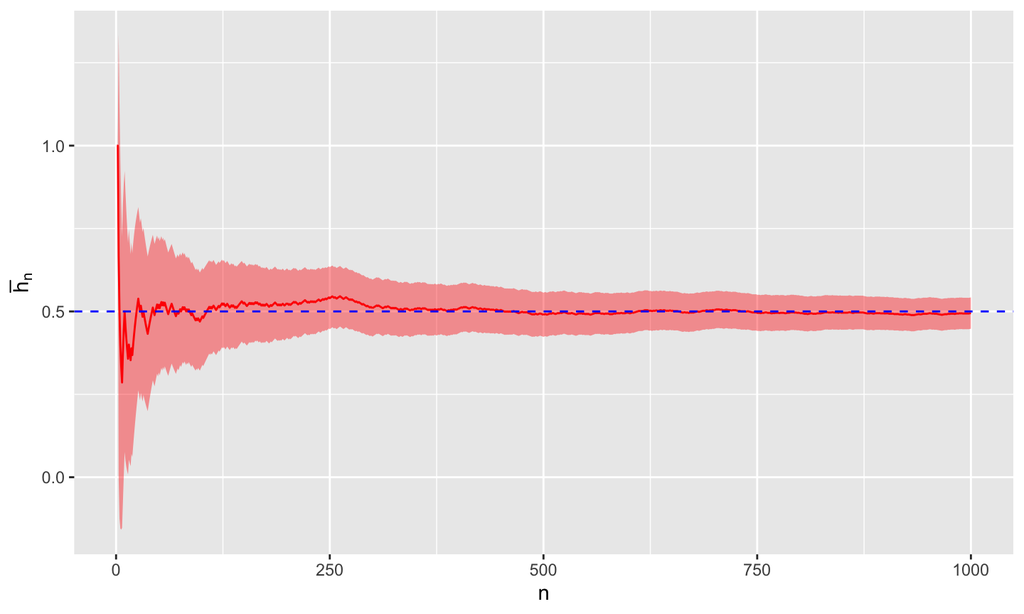

## Caution!

The result we proved that justifies the use of standard error is *asymptotic*. It only holds when \(n\) is very large, so we shouldn’t treat these as proper “confidence intervals”.

Nevertheless, the standard error provides a useful heuristic to assess convergence.

## Conclusion

## Conclusion

We’ve seen…

- That Monte-Carlo converges.
- How to assess error with the standard error.

Independent work:

1. Read Section 3.3 of “Introducing Monte Carlo Methods with R”
2. Attempt Exercise 3.5.
3. Optional: push it to github!